# Lecture 11

# Set up

```r
using <- function(...) {
    libs <- unlist(list(...))
    need <- libs <- libs[!unlist(lapply(libs, require, character.only = T))]
    if(length(need) > 0){
        install.packages(need, repos = "https://cloud.r-project.org")
        need <- need[!unlist(lapply(need, require, character.only = T))]
        if (length(need) > 0) {
          if (!requireNamespace("BiocManager", quietly = T))
            install.packages("BiocManager")
          BiocManager::install(need)
        }
    }
    lapply(libs, require, character.only = T)
}
using("tidyverse", "readxl", "TCGAbiolinks", "ComplexHeatmap", "circlize",
      "MultiAssayExperiment", "DT", "DiffBind", "DESeq2","future.apply", "progressr",
      "karyoploteR", "TxDb.Hsapiens.UCSC.hg38.knownGene", "org.Hs.eg.db", "ChIPseeker")
```

# Download

We obtain the needed TCGA data on esophageal carcinoma patients using `TCGAbiolinks`. This takes a bit of time so it’s been done already and the outputs stored in the provided RData file.

```r
load('lec11.RData')
```

This “Download” section doesn’t need to be ran in class, they’re just for your reference

Accessing the ATAC-seq data is a bit different. Let’s first see what’s available

```r
readr::read_tsv("https://gdc.cancer.gov/files/public/file/ATACseq-AWG_Open_GDC-Manifest.txt")
```

| filename | size | id | md5 |
| --- | --- | --- | --- |
| TCGA-ATAC_PanCancer_PeakSet.txt | 37522221 | 116ebba2-d284-485b-9121-faf73ce0a4ec | dbcaa696c62a99c4d625c176eb8ce3f3 |
| TCGA-ATAC_DataS1_DonorsAndStats_v4.xlsx | 251795 | 148b8d1e-a132-48f6-8e40-9ca96aa2f9b2 | f424a4aa2184de6e1b129ab6994b29f8 |
| MESO_bigWigs.tgz | 1507969705 | 165a6103-8d8b-4e1e-afd4-e68fe81f30e6 | acd81af5c7ddbbc08fdb0ed8832cdd5e |
| TCGA-ATAC_DataS5_GWAS_v2.xlsx | 999661 | 17bdb321-45cf-4476-9dcb-d68f2f192e7b | 2a8196fbda1736dd01cd9e53fb553095 |
| COAD_bigWigs.tgz | 8939070313 | 26b96cd9-dce0-4340-b15f-9e0afbb6312c | ef6a3e7f1a86e198223befa0442b5fff |
| TCGA-ATAC_PanCan_Raw_Counts.txt | 1241263873 | 26f78bd9-45f3-4468-9aab-9a0a7ddbc6ed | f1270f619894cdab381e50afa1b791c6 |
| TGCT_bigWigs.tgz | 2058854449 | 2f27b5c3-73ce-4ddc-9c04-eb6187875788 | b31098961708e66ef9c550534aa3321f |
| TCGA-ATAC_DataS6_Footprinting_v1.xlsx | 19544445 | 340e5b6c-991f-42c2-8877-c8c4043e8f98 | 62a823f620a4ddffa5bdd5bc71bd3318 |
| TCGA-ATAC_DataS10_WGS-ATAC_v2_Open.xlsx | 893110 | 3443e515-69b8-413d-969e-c9390070789b | ed5836348d58b500b8d58332aa3f45e5 |
| TCGA-ATAC_Cancer_Type-specific_Count_Matrices_log2norm_counts.zip | 632769396 | 38b8f311-f3a4-4746-9829-b8e3edb9c157 | c31893739baa05a95dc57f6ab38150b4 |

[output cut: 37 more lines]

The ATAC-seq count matrices can be then retrieved

```r
file <- "TCGA-ATAC_Cancer_Type-specific_Count_Matrices_log2norm_counts.zip"
query <- GDCquery_ATAC_seq(file.type = file)
GDCdownload(query,directory = "data") # 632 MB
zipfile <- dir(path = "data", recursive = TRUE, pattern = file, full.names = TRUE)
unzip(zipfile = zipfile, files = "ESCA_log2norm.txt",exdir = "data")
esca.peaks <- readr::read_tsv("data/ESCA_log2norm.txt")

file <- "TCGA-ATAC_Cancer_Type-specific_Count_Matrices_raw_counts.zip"
query <- GDCquery_ATAC_seq(file.type = file)
GDCdownload(query,directory = "data") # 632 MB
zipfile <- dir(path = "data", recursive = TRUE, pattern = file, full.names = TRUE)
unzip(zipfile = zipfile, files = "ESCA_raw_counts.txt",exdir = "data")
esca.peaks.raw <- readr::read_tsv("data/ESCA_raw_counts.txt")
```

| seqnames | start | end | name | score | ESCA_1E6AC686_96C2_46C4_A451_12D30114DD06_X012_S02_L027_B1_T1_P024 | ESCA_1E6AC686_96C2_46C4_A451_12D30114DD06_X012_S02_L028_B1_T2_P026 |
| --- | --- | --- | --- | --- | --- | --- |
| chr1 | 10178 | 10679 | ESCA_1 | 2.084220 | 24 | 19 |
| chr1 | 180639 | 181140 | ESCA_2 | 2.166890 | 53 | 42 |
| chr1 | 181191 | 181692 | ESCA_3 | 6.633801 | 39 | 35 |
| chr1 | 184244 | 184745 | ESCA_4 | 2.587929 | 24 | 18 |
| chr1 | 267753 | 268254 | ESCA_5 | 4.970492 | 22 | 25 |
| chr1 | 778468 | 778969 | ESCA_6 | 32.766303 | 389 | 347 |

Likewise for the significantly correlated gene-peak pairs from the [paper](https://science.sciencemag.org/content/362/6413/eaav1898)

```r
query.links <- GDCquery_ATAC_seq(file.type = "TCGA-ATAC_DataS7_PeakToGeneLinks_v2.xlsx")
GDCdownload(query.links, directory = "data")
links.file <- dir(path = "data", recursive = TRUE, full.names = TRUE,
                  pattern = "TCGA-ATAC_DataS7_PeakToGeneLinks_v2.xlsx")
peak.to.gene.links <- readxl::read_xlsx(path = links.file,sheet = 1,skip = 30)
```

| Chromosome | Start | End | hg19_Chromosome | hg19_Start | hg19_End | Peak_ID | Peak_Name | Linked_Distance | Linked_Gene | Linked_Gene_Start | Linked_Gene_Type | Raw_Correlation | Raw_FDR | Nearest_Gene_Distance | Nearest_Gene | Peak_Type | Link_ID | Correlation_Post_CNA | FDR_Post_CNA | Enhancer_ID | Enhancer_Annotation |
| --- | --- | --- | --- | --- | --- | --- | --- | --- | --- | --- | --- | --- | --- | --- | --- | --- | --- | --- | --- | --- | --- |
| chr1 | 818525 | 819026 | chr1 | 753905 | 754406 | 22 | ACC_6 | 1405 | FAM87B | 817371 | lincRNA | 0.4804936 | 0.004409290 | -1062 | RP11-206L10.8 | Exon | 1 | 0.4804936 | 0.004648329 | FAM87B_p1 | ClusterDriven |
| chr1 | 917307 | 917808 | chr1 | 852687 | 853188 | 49 | PRAD_18 | 92420 | LINC01128 | 825138 | processed_transcript | 0.4622655 | 0.006932681 | 3387 | RP11-54O7.2 | Exon | 2 | 0.4622655 | 0.007370947 | LINC01128_p1 | ClusterDriven |
| chr1 | 909955 | 910456 | chr1 | 845335 | 845836 | 42 | LGG_8 | 5372 | RP11-54O7.16 | 904834 | lincRNA | 0.4736259 | 0.005242449 | -1227 | RP11-54O7.1 | Intron | 3 | 0.4736259 | 0.005542648 | RP11-54O7.16_p1 | ClusterDriven |
| chr1 | 917307 | 917808 | chr1 | 852687 | 853188 | 49 | PRAD_18 | 12724 | RP11-54O7.16 | 904834 | lincRNA | 0.4992224 | 0.002704261 | 3387 | RP11-54O7.2 | Exon | 4 | 0.4992224 | 0.002835719 | RP11-54O7.16_p2 | Heterogeneous |
| chr1 | 923623 | 924124 | chr1 | 859003 | 859504 | 53 | PCPG_25 | 19040 | RP11-54O7.16 | 904834 | lincRNA | 0.4654092 | 0.006421792 | -1004 | SAMD11 | Distal | 5 | 0.4654092 | 0.006814146 | RP11-54O7.16_p3 | ClusterDriven |
| chr1 | 909955 | 910456 | chr1 | 845335 | 845836 | 42 | LGG_8 | -1229 | RP11-54O7.1 | 911435 | lincRNA | 0.4618344 | 0.007005599 | -1227 | RP11-54O7.1 | Intron | 6 | 0.4618344 | 0.007449626 | RP11-54O7.1_m1 | ClusterDriven |

Some annotations for the ATAC-seq samples are also needed

```r
samples.ids <- read_tsv("https://api.gdc.cancer.gov/data/7a3d7067-09d6-4acf-82c8-a1a81febf72c") %>%
  mutate(samle = substr(Case_ID, 1, 16))
```

| bam_prefix | stanfordUUID | aliquot_id | Case_UUID | Case_ID | sample |
| --- | --- | --- | --- | --- | --- |
| BRCA-000CFD9F-ADDF-4304-9E60-6041549E189C-X017-S06-L011-B1-T1-P040 | 000CFD9F-ADDF-4304-9E60-6041549E189C | TCGA-A7-A13F-01A-31-A615-42 | 2cf68894-168b-458b-af4f-53cad72989a8 | TCGA-A7-A13F-01A-31-A615-42 | TCGA-A7-A13F-01A |
| BRCA-000CFD9F-ADDF-4304-9E60-6041549E189C-X017-S06-L012-B1-T2-P046 | 000CFD9F-ADDF-4304-9E60-6041549E189C | TCGA-A7-A13F-01A-31-A615-42 | 2cf68894-168b-458b-af4f-53cad72989a8 | TCGA-A7-A13F-01A-31-A615-42 | TCGA-A7-A13F-01A |
| PCPG-007124EC-1F9B-4FCB-BC6E-DB8C25FD9146-X033-S03-L098-B1-T1-P073 | 007124EC-1F9B-4FCB-BC6E-DB8C25FD9146 | TCGA-RM-A68W-01A-31-A644-42 | 1a1cf490-8bd4-4a99-bf3a-34f06435de86 | TCGA-RM-A68W-01A-31-A644-42 | TCGA-RM-A68W-01A |
| PCPG-007124EC-1F9B-4FCB-BC6E-DB8C25FD9146-X033-S03-L100-B1-T2-P077 | 007124EC-1F9B-4FCB-BC6E-DB8C25FD9146 | TCGA-RM-A68W-01A-31-A644-42 | 1a1cf490-8bd4-4a99-bf3a-34f06435de86 | TCGA-RM-A68W-01A-31-A644-42 | TCGA-RM-A68W-01A |
| STAD-00DFAA4D-DE64-4476-9546-18E728653046-X029-S06-L011-B1-T1-P072 | 00DFAA4D-DE64-4476-9546-18E728653046 | TCGA-BR-A4J1-01A-31-A646-42 | e9a98a44-83f2-490c-b053-1e953ebd4e7e | TCGA-BR-A4J1-01A-31-A646-42 | TCGA-BR-A4J1-01A |
| STAD-00DFAA4D-DE64-4476-9546-18E728653046-X029-S06-L012-B1-T2-P077 | 00DFAA4D-DE64-4476-9546-18E728653046 | TCGA-BR-A4J1-01A-31-A646-42 | e9a98a44-83f2-490c-b053-1e953ebd4e7e | TCGA-BR-A4J1-01A-31-A646-42 | TCGA-BR-A4J1-01A |

Finally we’ll need RNA-seq data as well for integration

```r
# normalized counts
query <- GDCquery(
  project = "TCGA-ESCA",
  data.category = "Transcriptome Profiling",
  data.type = "Gene Expression Quantification",
  workflow.type = "HTSeq - FPKM-UQ",
  sample.type = "Primary Tumor"
)
GDCdownload(query, directory = "data") # 99 Mb
esca.rna <- GDCprepare(
  query = query,
  directory = "data"
)
rownames(esca.rna) <- values(esca.rna)$external_gene_name

# raw counts
query <- GDCquery(
  project = "TCGA-ESCA",
  data.category = "Transcriptome Profiling",
  data.type = "Gene Expression Quantification",
  workflow.type = "HTSeq - Counts",
  sample.type = "Primary Tumor"
)
GDCdownload(query, directory = "data") # 99 Mb
esca.rna.raw <- GDCprepare(
  query = query,
  directory = "data"
)
rownames(esca.rna.raw) <- values(esca.rna.raw)$external_gene_name
```

```
## class: RangedSummarizedExperiment
## dim: 56602 161
## metadata(1): data_release
## assays(1): HTSeq - Counts
## rownames(56602): TSPAN6 TNMD ... LINC01144 AC007389.5
## rowData names(3): ensembl_gene_id external_gene_name
##   original_ensembl_gene_id
## colnames(161): TCGA-JY-A93F-01A-21R-A37I-31
##   TCGA-LN-A4A9-01A-11R-A28J-31 ... TCGA-Z6-A9VB-01A-21R-A37I-31
##   TCGA-VR-A8EU-01A-11R-A36D-31
## colData names(141): barcode patient ... paper_GEA-CIN Integrated
##   Cluster - MKL-KNN-4 paper_GEA-CIN Integrated Cluster - MKL-KNN-7
```

# Differential analysis

Let’s begin with a simple differential accessibility analysis. While usually one would use raw counts combined with frameworks such as DiffBind that we used in the last lecture (which uses DESeq2/edgeR under the hood), for the sake of simplicity we’ll directly apply t-tests to the normalized and log-transformed enrichment values

## Renaming samples

We first map the ATAC-seq-specific sample IDs to the more conventional TCGA barcodes

```r
atac <- esca.peaks
colnames(atac)[-c(1:5)] <- colnames(atac)[-c(1:5)] %>%
  gsub('_', '-', .) %>%
  match(samples.ids$bam_prefix) %>%
  samples.ids$Case_ID[.]
```

| seqnames | start | end | name | score | TCGA-IG-A51D-01A-31-A616-42 | TCGA-IG-A51D-01A-31-A616-42 |
| --- | --- | --- | --- | --- | --- | --- |
| chr1 | 10180 | 10679 | ESCA_1 | 2.084220 | 1.440835 | 1.220656 |
| chr1 | 180641 | 181140 | ESCA_2 | 2.166890 | 2.545305 | 2.229090 |
| chr1 | 181193 | 181692 | ESCA_3 | 6.633801 | 2.096789 | 1.978599 |
| chr1 | 184246 | 184745 | ESCA_4 | 2.587929 | 1.440835 | 1.158167 |
| chr1 | 267755 | 268254 | ESCA_5 | 4.970492 | 1.337133 | 1.540553 |
| chr1 | 778470 | 778969 | ESCA_6 | 32.766303 | 5.476800 | 5.351221 |

## Types

We first retrieve some metadata, such as the specific type of esophageal carcinoma

```r
non.cts.idx <- 1:5
samples.info <- colDataPrepare(unique(colnames(atac)[-c(non.cts.idx)]))
## Starting to add information to samples
##  => Add clinical information to samples
##  => Adding TCGA molecular information from marker papers
##  => Information will have prefix 'paper_'
## esca subtype information from:doi:10.1038/nature20805
```

| sample | primary_diagnosis |
| --- | --- |
| TCGA-IG-A51D-01A | Squamous cell carcinoma, NOS |
| TCGA-LN-A9FQ-01A | Squamous cell carcinoma, NOS |
| TCGA-L7-A6VZ-01A | Adenocarcinoma, NOS |
| TCGA-L5-A4OE-01A | Adenocarcinoma, NOS |
| TCGA-LN-A49O-01A | Squamous cell carcinoma, NOS |
| TCGA-IG-A7DP-01A | Adenocarcinoma, NOS |
| TCGA-LN-A4A5-01A | Squamous cell carcinoma, NOS |
| TCGA-IG-A4P3-01A | Squamous cell carcinoma, NOS |
| TCGA-IG-A3YA-01A | Squamous cell carcinoma, NOS |
| TCGA-IG-A4QS-01A | Adenocarcinoma, NOS |

[output cut: 8 more lines]

Those are then added to the sample names to help us keep track

```r
samples.map <- paste0(samples.info$primary_diagnosis, "-", samples.info$sample) %>%
  gsub("Squamous cell carcinoma","ESCC", .) %>%
  gsub("Adenocarcinoma","ESAD", .) %>%
  gsub(",| |NOS","", .)
colnames(atac)[-non.cts.idx] <- substr(colnames(atac)[-c(non.cts.idx)], 1, 16) %>%
  match(substr(samples.map, 6, 21)) %>%
  samples.map[.]
colnames(atac)[-non.cts.idx]
```

```
##  [1] "ESCC-TCGA-IG-A51D-01A" "ESCC-TCGA-IG-A51D-01A" "ESCC-TCGA-LN-A9FQ-01A"
##  [4] "ESCC-TCGA-LN-A9FQ-01A" "ESAD-TCGA-L7-A6VZ-01A" "ESAD-TCGA-L7-A6VZ-01A"
##  [7] "ESAD-TCGA-L5-A4OE-01A" "ESAD-TCGA-L5-A4OE-01A" "ESCC-TCGA-LN-A49O-01A"
## [10] "ESCC-TCGA-LN-A49O-01A" "ESAD-TCGA-IG-A7DP-01A" "ESAD-TCGA-IG-A7DP-01A"
## [13] "ESCC-TCGA-LN-A4A5-01A" "ESCC-TCGA-LN-A4A5-01A" "ESCC-TCGA-IG-A4P3-01A"
## [16] "ESCC-TCGA-IG-A3YA-01A" "ESCC-TCGA-IG-A3YA-01A" "ESAD-TCGA-IG-A4QS-01A"
## [19] "ESAD-TCGA-IG-A4QS-01A" "ESCC-TCGA-LN-A7HX-01A" "ESCC-TCGA-LN-A7HX-01A"
## [22] "ESCC-TCGA-LN-A8HZ-01A" "ESCC-TCGA-LN-A4A2-01A" "ESCC-TCGA-LN-A4A2-01A"
## [25] "ESCC-TCGA-LN-A4MR-01A" "ESCC-TCGA-IG-A625-01A" "ESCC-TCGA-IG-A625-01A"
## [28] "ESCC-TCGA-LN-A49W-01A" "ESCC-TCGA-LN-A49W-01A" "ESAD-TCGA-IC-A6RE-01A"
## [31] "ESAD-TCGA-IC-A6RE-01A" "ESAD-TCGA-M9-A5M8-01A" "ESAD-TCGA-M9-A5M8-01A"
```

## Constructing object

Next we’ll create a `RangedSummarizedExperiment` object that neatly stores everything

```r
counts <- atac[,-c(1:5)] %>% as.matrix()
rowRanges <- makeGRangesFromDataFrame(atac)
rowRanges$score <- atac$score
rowRanges$name <- atac$name
names(rowRanges) <- paste(atac$name, atac$seqnames, atac$start,atac$end, sep = "_")
rownames(counts) <- names(rowRanges)
colData <- DataFrame(unique(left_join(samples.info,samples.ids)))
rownames(colData) <- colnames(counts)
esca.rse <- SummarizedExperiment(
  assays = SimpleList(log2norm = as.matrix(counts)),
  rowRanges = rowRanges,
  colData = colData
)

# replicates for each patient will be renamed rep1 & rep2
duplicated.idx <- duplicated(colnames(esca.rse))
colnames(esca.rse)[!duplicated.idx] <- paste0(colnames(esca.rse)[!duplicated.idx], "_rep1")
colnames(esca.rse)[duplicated.idx] <- paste0(colnames(esca.rse)[duplicated.idx], "_rep2")

esca.rse
```

```
## class: RangedSummarizedExperiment
## dim: 126935 33
## metadata(0):
## assays(1): log2norm
## rownames(126935): ESCA_1_chr1_10180_10679 ESCA_2_chr1_180641_181140 ...
##   ESCA_126943_chrX_155985136_155985635
##   ESCA_126944_chrX_156030008_156030507
## rowData names(2): score name
## colnames(33): ESCC-TCGA-IG-A51D-01A_rep1 ESCC-TCGA-IG-A51D-01A_rep2 ...
##   ESAD-TCGA-M9-A5M8-01A_rep1 ESAD-TCGA-M9-A5M8-01A_rep2
## colData names(145): barcode patient ... Case_UUID Case_ID
```

## T-tests

We now apply a simple T-test to every single peak

This may take a while to run, so you can skip it in class, as the output is included in the RData file

```r
# set up parallelization
plan(multisession(workers = 24)) # adjust this based on how many cores you have / want to use

# progress bar
handlers(global = TRUE)
handlers("progress")

# sample grouping
escc.idx <- which(esca.rse$primary_diagnosis == "Squamous cell carcinoma, NOS")
esad.idx <- which(esca.rse$primary_diagnosis == "Adenocarcinoma, NOS")

# tests
with_progress({
  p <- progressor(steps = length(esca.rse))
  result <- future_apply(assay(esca.rse), 1, function(peak) {
    p()
    t.test(peak[escc.idx], peak[esad.idx], conf.level = TRUE) %>%
      {c(raw_p_value = .$p.value,
         ESCC_minus_ESAD = .$estimate[1] - .$estimate[2])}
  }) %>% t() %>% as_tibble() %>% mutate(FDR = p.adjust(raw_p_value, method = 'fdr'))
})
```

| raw_p_value | ESCC_minus_ESAD | FDR |
| --- | --- | --- |
| 0.1767724 | -0.2429201 | 0.2723660 |
| 0.7296868 | 0.0863647 | 0.8038150 |
| 0.0063019 | -0.8747959 | 0.0185693 |
| 0.0144905 | -0.7515080 | 0.0366449 |
| 0.7252435 | 0.0882583 | 0.8003372 |
| 0.4940274 | -0.1033259 | 0.6043344 |

## Results

The results can be visualized as we’ve done for differential gene expression

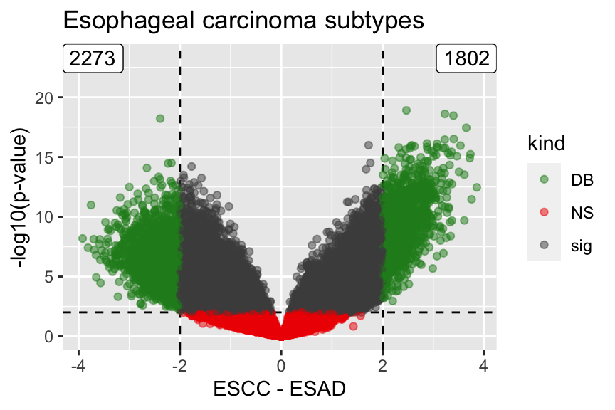

```r
d <- result %>%
  dplyr::rename(x = ESCC_minus_ESAD, y = raw_p_value) %>%
  mutate(kind = case_when(abs(x) > 2 & y < .01 ~ 'DB',
                          abs(x) > 2 ~ 'big',
                          y < .01 ~ 'sig',
                          T ~ 'NS'),
         y = -log10(y))
ct <- na.omit(d) %>%
  dplyr::filter(kind == 'DB') %>%
  mutate(up = x > 0) %>%
  dplyr::count(up) %>%
  mutate(x = ifelse(up, Inf, -Inf),
         y = Inf,
         h = as.numeric(up))
ggplot(d, aes(x, y, color = kind)) +
  geom_vline(xintercept = c(-2, 2), linetype = 'dashed') +
  geom_hline(yintercept = 2, linetype = 'dashed') +
  geom_point(alpha = .5) +
  geom_label(aes(x = x, y = y, label = n, hjust = h),
             vjust = 1, data = ct, inherit.aes = F) +
  scale_y_continuous() +
  scale_color_manual(values = c('forestgreen', 'red2', 'grey30',  'royalblue')) +
  labs(x = 'ESCC - ESAD', y = '-log10(p-value)', title = 'Esophageal carcinoma subtypes')
```

## Example locus

We will take one of the most differentially accessible sites on chromosome 20 and visualize the raw data

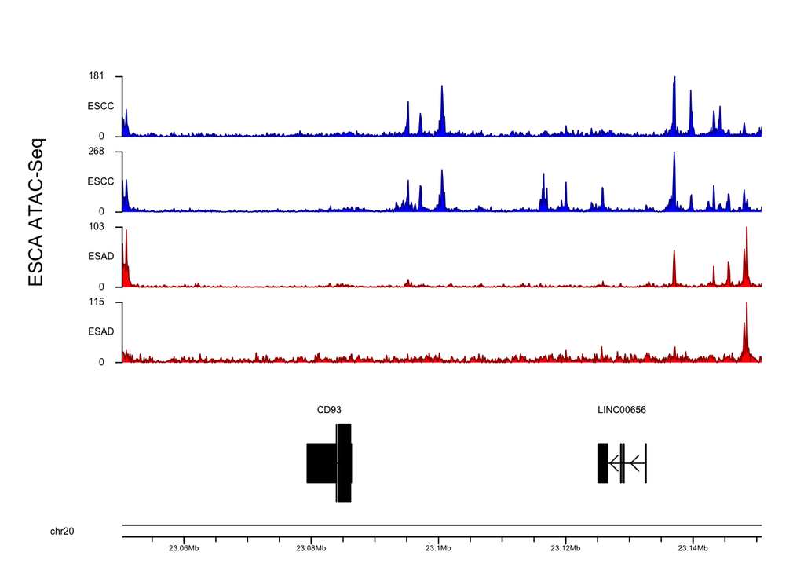

```r
# take a single DB site and extend +/- 50kb
plot.region <- rowRanges(esca.rse) %>%
  as_tibble() %>%
  cbind(result) %>%
  dplyr::filter(seqnames == 'chr20' & FDR < 1e-1) %>%
  slice_max(ESCC_minus_ESAD) %>%
  makeGRangesFromDataFrame() %>%
  `+`(50000)

# some plot settings
pp <- getDefaultPlotParams(plot.type = 1)
pp$leftmargin <- 0.15
pp$topmargin <- 15
pp$bottommargin <- 15
pp$ideogramheight <- 5
pp$data1inmargin <- 10
pp$data1outmargin <- 0

# the general region we want to show
kp <- plotKaryotype(zoom = plot.region, genome = "hg38", cex = 0.5, plot.params = pp)
kpAddBaseNumbers(kp, tick.dist = 20000, minor.tick.dist = 5000,
                 add.units = TRUE, cex = 0.4, tick.len = 3)

# we first plot the gene track
genes.data <- makeGenesDataFromTxDb(TxDb.Hsapiens.UCSC.hg38.knownGene,
                                    karyoplot = kp,
                                    plot.transcripts = TRUE,
                                    plot.transcripts.structure = TRUE) %>%
  addGeneNames() %>%
  mergeTranscripts()
kpPlotGenes(kp, data = genes.data, r0 = 0, r1 = 0.25, gene.name.cex = 0.5)


# the bigwig files we have
big.wig.files <- dir(path = "ESCA_bigwig_chr20/", pattern = ".bw", full.names = T)

# we only plot the bigwig tracks in the top 70% of the panel (as we have genes at the bottom)
out.at <- autotrack(1:length(big.wig.files),
                    length(big.wig.files),
                    margin = 0.3,
                    r0 = 0.3,
                    r1 = 1)

# we label that we're plotting ATAC-seq data
kpAddLabels(kp,
            labels = "ESCA ATAC-Seq",
            r0 = out.at$r0,
            r1 = out.at$r1,
            side = "left",
            cex = 1,
            srt = 90,
            pos = 3,
            label.margin = 0.1)

# plot individual tracks
for(i in seq_len(length(big.wig.files))) {
  bigwig.file <- big.wig.files[i]

  # we use autotrack to automatically partition the predefined plotting area
  at <- autotrack(i, length(big.wig.files), r0 = out.at$r0, r1 = out.at$r1, margin = 0.2)

  # show bigwig score as area plot
  kp <- kpPlotBigWig(kp,
                     data = bigwig.file,
                     ymax = "visible.region",
                     r0 = at$r0,
                     col = ifelse(grepl("ESCC",bigwig.file),"#0000FF","#FF0000"),
                     r1 = at$r1)

  # label y-axis
  kpAxis(kp,
         ymin = 0,
         ymax = ceiling(kp$latest.plot$computed.values$ymax),
         numticks = 2,
         r0 = at$r0,
         r1 = at$r1,
         cex = 0.5)

  # label tumour type
  kpAddLabels(kp,
              labels = ifelse(grepl("ESCC", bigwig.file), "ESCC", "ESAD"),
              r0 = at$r0,
              r1 = at$r1,
              cex = 0.5,
              label.margin = 0.01)
}
```

## Genomic localization

One of the first things we can do is to examine where the differentially accessible regions fall with respect to the set of all ATAC-seq peaks

```r
pks <- list(ESCC = granges(esca.rse)[result$ESCC_minus_ESAD > 2 & result$FDR < .01],
            ESAD = granges(esca.rse)[result$ESCC_minus_ESAD < -2 & result$FDR < .01],
            all = granges(esca.rse))
anns <- lapply(pks, annotatePeak, TxDb = TxDb.Hsapiens.UCSC.hg38.knownGene,
               tssRegion = c(-3000, 3000), annoDb = 'org.Hs.eg.db')
```

```r
plotAnnoBar(anns)
```

[figure not shown]

```r
plotDistToTSS(anns)
```

[figure not shown]

To further follow up, we’ll take a closer look at the differentially accessible regions using [GREAT](http://great.stanford.edu/public/html/index.php) (web tool) and [HOMER](http://homer.ucsd.edu/homer/index.html) (on the cluster).

# Multi-omics integration

While the ATAC-seq dataset by itself is quite rich, combining it with expression data can yield further insights

## Merging

We’ll need to take a few steps before combining the two modalities

### Construct object

While the RNA-seq data already comes in a `RangedSummarizedExperiment`, we’ll have to again create one for the ATAC-seq data

```r
# make object
esca.peaks.se <- esca.peaks %>%
  dplyr::select(-c("score", "name")) %>%
  makeSummarizedExperimentFromDataFrame()
rowRanges(esca.peaks.se)$score <- esca.peaks$score
rowRanges(esca.peaks.se)$name <- esca.peaks$name

# rename samples
colnames(esca.peaks.se) <- colnames(esca.peaks.se) %>%
  gsub("_", "-", .) %>%
  match(samples.ids$bam_prefix) %>%
  samples.ids$Case_ID[.]

# drop tech reps
esca.peaks.se <- esca.peaks.se[,!duplicated(colnames(esca.peaks.se))]
```

### Define mapping

We then proceed and merge the ATAC-seq and RNA-seq datasets

```r
sampleMap <- S4Vectors::DataFrame(
  assay = factor(x = c(rep("RNA", ncol(esca.rna)), rep("ATAC", ncol(esca.peaks.se))),
                 levels = c("RNA","ATAC")),
  primary = c(colnames(esca.rna), colnames(esca.peaks.se)) %>% substr(1,16),
  colname = c(colnames(esca.rna), colnames(esca.peaks.se))
)
```

| assay | primary | colname |
| --- | --- | --- |
| RNA | TCGA-Z6-A8JE-01A | TCGA-Z6-A8JE-01A-11R-A37I-31 |
| RNA | TCGA-IG-A5S3-01A | TCGA-IG-A5S3-01A-11R-A28J-31 |
| RNA | TCGA-2H-A9GL-01A | TCGA-2H-A9GL-01A-12R-A37I-31 |
| RNA | TCGA-L5-A8NI-01A | TCGA-L5-A8NI-01A-11R-A37I-31 |
| RNA | TCGA-XP-A8T8-01A | TCGA-XP-A8T8-01A-11R-A36D-31 |
| RNA | TCGA-L5-A4OG-01A | TCGA-L5-A4OG-01A-11R-A260-31 |
| RNA | TCGA-L5-A88Z-01A | TCGA-L5-A88Z-01A-11R-A36D-31 |
| RNA | TCGA-L5-A8NE-01A | TCGA-L5-A8NE-01A-11R-A37I-31 |
| RNA | TCGA-VR-A8Q7-01A | TCGA-VR-A8Q7-01A-11R-A37I-31 |
| RNA | TCGA-L5-A8NV-01A | TCGA-L5-A8NV-01A-11R-A37I-31 |

[output cut: 169 more lines]

### Additional metadata

We also retrieve some patient information for the matched samples

```r
matched.samples <- intersect(colnames(esca.rna) %>% substr(1,16),
                             colnames(esca.peaks.se) %>% substr(1,16))
colData <-  matched.samples %>% unique() %>% colDataPrepare()
## Starting to add information to samples
##  => Add clinical information to samples
##  => Adding TCGA molecular information from marker papers
##  => Information will have prefix 'paper_'
## esca subtype information from:doi:10.1038/nature20805
```

|  | barcode | patient | sample | shortLetterCode | definition | sample_submitter_id | sample_type_id | oct_embedded | sample_id | submitter_id | state | is_ffpe | sample_type | tissue_type | days_to_collection | initial_weight | pathology_report_uuid | synchronous_malignancy | ajcc_pathologic_stage | tumor_stage | days_to_diagnosis | treatments | last_known_disease_status | tissue_or_organ_of_origin | days_to_last_follow_up | ajcc_clinical_stage | age_at_diagnosis | primary_diagnosis | year_of_diagnosis | … |
| --- | --- | --- | --- | --- | --- | --- | --- | --- | --- | --- | --- | --- | --- | --- | --- | --- | --- | --- | --- | --- | --- | --- | --- | --- | --- | --- | --- | --- | --- | --- |
| TCGA-LN-A4A5-01A | TCGA-LN-A4A5-01A | TCGA-LN-A4A5 | TCGA-LN-A4A5-01A | TP | Primary solid Tumor | TCGA-LN-A4A5-01A | 01 | true | 65da0366-655b-4f34-ac56-1dc0d7a6d929 | TCGA-LN-A4A5 | released | FALSE | Primary Tumor | Not Reported | 270 | 350 | 68503132-C11A-4C30-9584-30E05AC30CDE | No | Stage IIA | stage iia | 0 |  | not reported | Middle third of esophagus | 3 | Stage IIA | 18160 | Squamous cell carcinoma, NOS | 2011 | … |
| TCGA-IG-A625-01A | TCGA-IG-A625-01A | TCGA-IG-A625 | TCGA-IG-A625-01A | TP | Primary solid Tumor | TCGA-IG-A625-01A | 01 | true | f08fd279-e493-4b09-9698-308f2d8738bb | TCGA-IG-A625 | released | FALSE | Primary Tumor | Not Reported | 102 | 410 | 0F8E354D-389D-4297-80E8-DBE7629A7D71 | No | Stage IIIB | stage iiib | 0 |  | not reported | Lower third of esophagus | 11 | NA | 22070 | Squamous cell carcinoma, NOS | 2012 | … |
| TCGA-LN-A8HZ-01A | TCGA-LN-A8HZ-01A | TCGA-LN-A8HZ | TCGA-LN-A8HZ-01A | TP | Primary solid Tumor | TCGA-LN-A8HZ-01A | 01 | true | 2509370a-e916-4372-9e05-8a7b4aa7b9b9 | TCGA-LN-A8HZ | released | FALSE | Primary Tumor | Not Reported | 200 | 330 | 2A46F2F9-9506-4DA0-8B8D-2A558B7AE0FB | No | Stage IIA | stage iia | 0 |  | not reported | Middle third of esophagus | 375 | NA | 20510 | Squamous cell carcinoma, NOS | 2013 | … |
| TCGA-IG-A4P3-01A | TCGA-IG-A4P3-01A | TCGA-IG-A4P3 | TCGA-IG-A4P3-01A | TP | Primary solid Tumor | TCGA-IG-A4P3-01A | 01 | true | 784021b2-5f94-48f9-9df7-854b4fbdf802 | TCGA-IG-A4P3 | released | FALSE | Primary Tumor | Not Reported | 198 | 1200 | AEAAD0A0-642D-45F5-99C0-34DD484FC590 | No | Stage IIB | stage iib | 0 |  | not reported | Middle third of esophagus | 1 | NA | 17860 | Squamous cell carcinoma, NOS | 2012 | … |
| TCGA-LN-A9FQ-01A | TCGA-LN-A9FQ-01A | TCGA-LN-A9FQ | TCGA-LN-A9FQ-01A | TP | Primary solid Tumor | TCGA-LN-A9FQ-01A | 01 | true | cde405e5-a694-4ccf-b08d-bfa4d6843291 | TCGA-LN-A9FQ | released | FALSE | Primary Tumor | Not Reported | 115 | 290 | 7D7169E4-0F31-4C12-BC3E-1BE304FECA09 | No | Stage IIA | stage iia | 0 |  | not reported | Middle third of esophagus | 391 | NA | 22717 | Squamous cell carcinoma, NOS | 2013 | … |
| TCGA-LN-A49W-01A | TCGA-LN-A49W-01A | TCGA-LN-A49W | TCGA-LN-A49W-01A | TP | Primary solid Tumor | TCGA-LN-A49W-01A | 01 | true | 25e6a27b-b015-4936-b57e-cf39dd5af9ba | TCGA-LN-A49W | released | FALSE | Primary Tumor | Not Reported | 500 | 630 | 38309E84-2CFD-4D1B-8AF4-D8F711679B26 | No | Stage III | stage iii | 0 |  | not reported | Middle third of esophagus | 403 | Stage III | 26910 | Squamous cell carcinoma, NOS | 2011 | … |
| TCGA-IG-A7DP-01A | TCGA-IG-A7DP-01A | TCGA-IG-A7DP | TCGA-IG-A7DP-01A | TP | Primary solid Tumor | TCGA-IG-A7DP-01A | 01 | true | 1ede390b-f04e-4865-8f1d-0c151fb78331 | TCGA-IG-A7DP | released | FALSE | Primary Tumor | Not Reported | 118 | 1890 | 563EF32E-3F03-41D9-AC7E-8FC8E82BDD35 | No | Stage IIIA | stage iiia | 0 |  | not reported | Lower third of esophagus | 452 | NA | 18364 | Adenocarcinoma, NOS | 2013 | … |
| TCGA-IG-A3YA-01A | TCGA-IG-A3YA-01A | TCGA-IG-A3YA | TCGA-IG-A3YA-01A | TP | Primary solid Tumor | TCGA-IG-A3YA-01A | 01 | true | aaadb48e-3c60-4ae4-b6eb-7b5f9c9d6544 | TCGA-IG-A3YA | released | FALSE | Primary Tumor | Not Reported | 115 | 840 | 41B0A7CF-11BD-477C-8315-49985775951B | No | Stage IIIA | stage iiia | 0 |  | not reported | Lower third of esophagus | 632 | NA | 19567 | Squamous cell carcinoma, NOS | 2012 | … |
| TCGA-LN-A49O-01A | TCGA-LN-A49O-01A | TCGA-LN-A49O | TCGA-LN-A49O-01A | TP | Primary solid Tumor | TCGA-LN-A49O-01A | 01 | true | 37a1045e-a566-4bc0-88ca-a54c5426a96d | TCGA-LN-A49O | released | FALSE | Primary Tumor | Not Reported | 605 | 330 | E00522D4-884E-4872-97A2-206126C8F03E | No | Stage IIA | stage iia | 0 |  | not reported | Middle third of esophagus | 408 | Stage IIA | 17237 | Squamous cell carcinoma, NOS | 2011 | … |
| TCGA-IG-A4QS-01A | TCGA-IG-A4QS-01A | TCGA-IG-A4QS | TCGA-IG-A4QS-01A | TP | Primary solid Tumor | TCGA-IG-A4QS-01A | 01 | true | 6844eb62-0bc3-43aa-8c0e-4a1191011500 | TCGA-IG-A4QS | released | FALSE | Primary Tumor | Not Reported | 79 | 930 | A1C91436-4532-43B8-95A8-CF502CDD3285 | No | Stage IIIB | stage iiib | 0 |  | not reported | Thoracic esophagus | 8 | NA | 26273 | Adenocarcinoma, NOS | 2012 | … |

[output cut: 6 more lines]

### Harmonization

The merged object will be a `MultiAssayExperiment` object

```r
mae <- MultiAssayExperiment(
  experiments = ExperimentList(list(
    RNA = esca.rna[, match(matched.samples, colnames(esca.rna) %>% substr(1,16))],
    ATAC = esca.peaks.se[, match(matched.samples, colnames(esca.peaks.se) %>% substr(1,16))]
  )),
  colData = colData,
  sampleMap = sampleMap,
  metadata = list(),
  drops = list()
)
```

```
## harmonizing input:
##   removing 147 sampleMap rows with 'colname' not in colnames of experiments
```

```
## A MultiAssayExperiment object of 2 listed
##  experiments with user-defined names and respective classes.
##  Containing an ExperimentList class object of length 2:
##  [1] RNA: RangedSummarizedExperiment with 56602 rows and 16 columns
##  [2] ATAC: RangedSummarizedExperiment with 126935 rows and 16 columns
## Features:
##  experiments() - obtain the ExperimentList instance
##  colData() - the primary/phenotype DFrame
##  sampleMap() - the sample availability DFrame
##  `$`, `[`, `[[` - extract colData columns, subset, or experiment
##  *Format() - convert into a long or wide DFrame
##  assays() - convert ExperimentList to a SimpleList of matrices
```

### Matching

Just to re-assure ourselves, we can see that indeed the same samples are found in both assay slots

```r
names(mae) %>%
  setNames(., .) %>%
  lapply(function(x) assay(mae, x) %>% colnames() %>% substr(1, 16)) %>%
  bind_cols()
```

| RNA | ATAC |
| --- | --- |
| TCGA-LN-A4A5-01A | TCGA-LN-A4A5-01A |
| TCGA-IG-A625-01A | TCGA-IG-A625-01A |
| TCGA-LN-A8HZ-01A | TCGA-LN-A8HZ-01A |
| TCGA-IG-A4P3-01A | TCGA-IG-A4P3-01A |
| TCGA-LN-A9FQ-01A | TCGA-LN-A9FQ-01A |
| TCGA-LN-A49W-01A | TCGA-LN-A49W-01A |
| TCGA-IG-A7DP-01A | TCGA-IG-A7DP-01A |
| TCGA-IG-A3YA-01A | TCGA-IG-A3YA-01A |
| TCGA-LN-A49O-01A | TCGA-LN-A49O-01A |
| TCGA-IG-A4QS-01A | TCGA-IG-A4QS-01A |
| TCGA-L7-A6VZ-01A | TCGA-L7-A6VZ-01A |
| TCGA-IC-A6RE-01A | TCGA-IC-A6RE-01A |
| TCGA-LN-A7HX-01A | TCGA-LN-A7HX-01A |
| TCGA-L5-A4OE-01A | TCGA-L5-A4OE-01A |
| TCGA-M9-A5M8-01A | TCGA-M9-A5M8-01A |
| TCGA-IG-A51D-01A | TCGA-IG-A51D-01A |

## Correlation

For the sake of time, we’ll just look at the shortest chromosome 21

```r
# expression matrix
em <- log2(assay(mae, 'RNA') + 1)
gs <- genes(TxDb.Hsapiens.UCSC.hg38.knownGene, filter = list(tx_chrom = 'chr21'))
gs$symbol <- mapIds(org.Hs.eg.db, gs$gene_id, "SYMBOL", "ENTREZID")
gs <- gs[gs$symbol %in% rownames(em)]
em <- em[gs$symbol,]

# accessibility matrix
am <- assay(mae, 'ATAC')
rownames(am) <- rowRanges(mae[['ATAC']]) %>%
  as_tibble() %>%
  mutate(idx = sprintf('%s:%d-%d', seqnames, start, end)) %>%
  pull(idx)
am <- am[grep('chr21', rownames(am)),]
```

1. Is that a reasonable range to assess cis-regulatory events? What is the typical distance between enhancers and promoters?

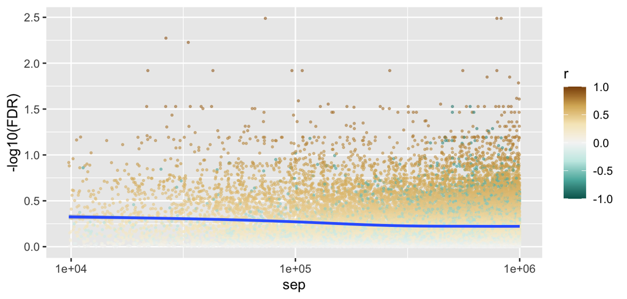

```r
# range to look at
hi <- 1e6
lo <- 1e4

# define upstream and downstream regions to check for overlap
up <- dn <- tss <- promoters(gs, upstream = 1, downstream = 0)
start(up) <- start(up) - hi
end(up) <- end(up) - lo

end(dn) <- end(dn) + hi
start(dn) <- start(dn) + lo

# peak coordinates
pks <- tibble(idx = rownames(am)) %>%
  separate(idx, c('chr', 'start', 'end'), '[:-]') %>%
  makeGRangesFromDataFrame()

# overlap and correlate
res <- list(up, dn) %>%
  lapply(function(x) {
    x <- trim(x)
    findOverlaps(x, pks) %>%
      as.data.frame() %>%
      group_by(queryHits, subjectHits) %>%
      do(cor.test(em[.$queryHits,], am[.$subjectHits,]) %>%
           {data.frame(p = .$p.value, r = .$estimate)})
  }) %>%
  bind_rows() %>%
  ungroup() %>%
  na.omit() %>%
  mutate(gene = rownames(em)[queryHits],
         tss = start(tss)[queryHits],
         peak = rownames(am)[subjectHits],
         mid = mid(pks)[subjectHits],
         sep = abs(mid - tss),
         FDR = p.adjust(p, method = 'fdr'))

# plot
ggplot(res, aes(x = sep, y = -log10(FDR))) +
  geom_point(aes(color = r), size = .5, alpha = .5) +
  scale_color_distiller(type = 'div', limits = c(-1, 1)) +
  geom_smooth() +
  scale_x_log10()
```

2. What is the farthest hit with $\text{FDR} < 0.01$? Show the actual expression / accessibility values as a scatter plot and color by condition

## Published results

Our results are quite limited, now let’s take a look at the results from the whole TCGA dataset that was performed in the associated publication

### Filter links

We’ve previously retrieved the complete set of link calls, and here we’ll focus on the ones anchored at ESCA peaks

```r
# create GRanges from links
peak.to.gene.links.merged.gr <- peak.to.gene.links.merged %>%
  makeGRangesFromDataFrame(keep.extra.columns = TRUE)

# exclude genes that we don't have expression data for
peak.to.gene.links.merged.gr <- peak.to.gene.links.merged.gr[
  peak.to.gene.links.merged.gr$Linked_Gene %in% rownames(assay(mae, "RNA"))
]

# overlap ATAC-seq peaks
hits.enhancer.atac.peaks <- findOverlaps(peak.to.gene.links.merged.gr, mae[["ATAC"]])

# filter
exp.mat <- peak.to.gene.links.merged.gr$Linked_Gene[queryHits(hits.enhancer.atac.peaks)] %>%
  assay(mae, "RNA")[.,]
atac.mat <- assay(mae, "ATAC")[subjectHits(hits.enhancer.atac.peaks),]

# we now have matched matrices
list(atac = atac.mat, rna = exp.mat) %>%
  lapply(dim) %>%
  bind_cols() %>%
  as.data.frame() %>%
  `rownames<-`(c('rows', 'columns'))
```

|  | atac | rna |
| --- | --- | --- |
| rows | 17747 | 17747 |
| columns | 16 | 16 |

### Plot

There’s a few parts to the plot, let’s go through them piece-by-piece

#### ATAC-seq

```r
# colorscale for the accessibility data
pal_atac <- colorRampPalette(c(
  "#053061", "#2166AC", "#4393C3", "#92C5DE", "#D1E5F0",
  "#FDDBC7", "#F4A582", "#D6604D", "#B2182B", "#67001F"
))(100)

# sample annotations
ha = HeatmapAnnotation(
  df = data.frame("Group" = mae$primary_diagnosis),
  show_annotation_name = TRUE,
  col = list(
    Group = c(
      "Squamous cell carcinoma, NOS" =  "red",
      "Adenocarcinoma, NOS" = "blue"
    )
  ),
  show_legend = TRUE,
  annotation_name_side = "left",
  annotation_name_gp = gpar(fontsize = 6)
)

# z-transform the data for greater visual contrast
atac.mat.row.z.score <- atac.mat %>% t() %>% scale() %>% t()
col.zscore <- colorRamp2(seq(-2, 2, by = 4/99), pal_atac)

# put together actual heatmap
ht_atac <- Heatmap(
  matrix = atac.mat.row.z.score[1:1000,],
  name ="ATAC-seq log2(counts)\nz-score rowwise",
  col = col.zscore,
  heatmap_legend_param = list(
    legend_width  = unit(3, "cm"),
    legend_direction = "horizontal",
    labels_gp = gpar(fontsize = 12),
    title_gp = gpar(fontsize = 12)
  ),
  show_column_names = FALSE,
  cluster_columns = TRUE,
  show_row_names = FALSE,
  cluster_rows = TRUE, # cluster will be based on ATAC-seq
  row_title = " ATAC-seq peaks",
  top_annotation = ha,
  column_names_gp = gpar(fontsize = 8),
  row_names_gp = gpar(fontsize = 4),
  column_title_gp = gpar(fontsize = 12),
  row_title_gp = gpar(fontsize = 12),
  use_raster = TRUE,
  raster_device = c("png"),
  raster_quality = 2
)
```

#### RNA-seq

```r
# colorscale for the expression data
pal_rna <- colorRampPalette(c(
  "#003C30", "#01665E", "#35978F", "#80CDC1", "#C7EAE5",
  "#F6E8C3", "#DFC27D", "#BF812D", "#8C510A", "#543005"
))(100)

# z-transform the data for greater visual contrast
exp.mat.row.z.score <- exp.mat %>% t() %>% scale() %>% t()
col.zscore <- colorRamp2(seq(-2, 2, by = 4/99), pal_rna)

# sample annotations, basically the same as above except on the other side
ha = HeatmapAnnotation(
  df = data.frame("Group" = mae$primary_diagnosis),
  show_annotation_name = FALSE,
  col = list(
    Group = c(
      "Squamous cell carcinoma, NOS" =  "red",
      "Adenocarcinoma, NOS" = "blue"
    )
  ),
  show_legend = TRUE,
  annotation_name_side = "right",
  annotation_name_gp = gpar(fontsize = 6)
)

# actual heatmap
ht_exp <- Heatmap(
  matrix = exp.mat.row.z.score[1:1000,],
  name ="RNA-seq FPKM-UQ\nz-score rowwise",
  col = col.zscore,
  column_names_gp = gpar(fontsize = 8),
  show_column_names = F,
  heatmap_legend_param = list(
    legend_width  = unit(3, "cm"),
    legend_direction = "horizontal",
    labels_gp = gpar(fontsize = 12),
    title_gp = gpar(fontsize = 12)
  ),
  show_row_names = FALSE,
  cluster_columns = FALSE,
  use_raster = TRUE,
  raster_device = c("png"),
  raster_quality = 2,
  cluster_rows = FALSE, # so we will use the clustering from the other heatmap
  row_title = "RNA-seq linked genes",
  row_title_side = "right",
  column_order = column_order(ht_atac),
  row_names_gp = gpar(fontsize = 4),
  top_annotation = ha,
  column_title_gp = gpar(fontsize = 12),
  row_title_gp = gpar(fontsize = 12)
)
```

#### Combined

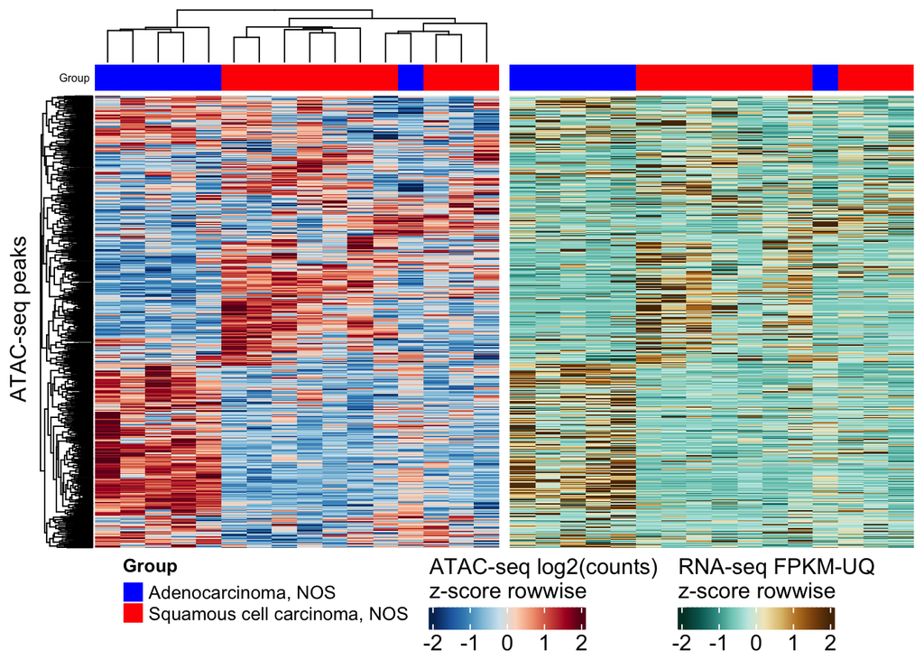

```r
draw(
  object = ht_atac + ht_exp,
  newpage = TRUE,
  merge_legends = TRUE,
  column_title_gp = gpar(fontsize = 12, fontface = "bold"),
  heatmap_legend_side = "bottom",
  annotation_legend_side = "bottom"
)
```